# 1 Basic genomic regions exploration

Project: Example run.

# 2 Introduction

This report is meant to help explore a set of genomic regions and was generated using the `regionReport` (Collado-Torres, Jaffe, and Leek, 2016) package. While the report is rich, it is meant to just start the exploration of the results and exemplify some of the code used to do so. If you need a more in-depth analysis for your specific data set you might want to use the `customCode` argument.

Most plots were made with using `ggplot2` (Wickham, 2016).

## 2.1 Code setup

```r
## knitrBoostrap and device chunk options
library('knitr')
opts_chunk$set(bootstrap.show.code = FALSE, dev = device, crop = NULL)
if(!outputIsHTML) opts_chunk$set(bootstrap.show.code = FALSE, dev = device, echo = FALSE)
```

```r
#### Libraries needed

## Bioconductor
library('bumphunter')
```

```
## locfit 1.5-9.12   2025-03-05
```

```r
library('derfinder')
library('derfinderPlot')
library('GenomeInfoDb')
library('GenomicRanges')
library('ggbio')

## Transcription database to use by default
if(is.null(txdb)) {
    library('TxDb.Hsapiens.UCSC.hg19.knownGene')
    txdb <- TxDb.Hsapiens.UCSC.hg19.knownGene::TxDb.Hsapiens.UCSC.hg19.knownGene
}

## CRAN
library('ggplot2')
if(!is.null(theme)) theme_set(theme)
library('grid')
library('gridExtra')
library('knitr')
library('RColorBrewer')
library('mgcv')
library('whisker')
library('DT')
library('sessioninfo')

#### Code setup

## For ggplot
tmp <- regions
names(tmp) <- seq_len(length(tmp))
regions.df <- as.data.frame(tmp)
regions.df$width <- width(tmp)
rm(tmp)

## Special subsets: need at least 3 points for a density plot
keepChr <- table(regions.df$seqnames) > 2
regions.df.plot <- subset(regions.df, seqnames %in% names(keepChr[keepChr]))

if(hasSignificant) {
    ## Keep only those sig
    regions.df.sig <- regions.df[significantVar, ]
    keepChr <- table(regions.df.sig$seqnames) > 2
    regions.df.sig <- subset(regions.df.sig, seqnames %in% names(keepChr[keepChr]))
}

## Find which chrs are present in the data set
chrs <- levels(seqnames(regions))

## areaVar initialize
areaVar <- NULL
```

# 3 Quality checks

```r
for(i in seq_len(length(pvalueVars))) {
    densityVarName <- names(pvalueVars[i])
    densityVarName <- ifelse(is.null(densityVarName), pvalueVars[i], densityVarName)
   cat(knit_child(text = whisker.render(templatePvalueDensityInUse, list(varName = pvalueVars[i], densityVarName = densityVarName)), quiet = TRUE), sep = '\n')
}
```

## 3.1 Q-values

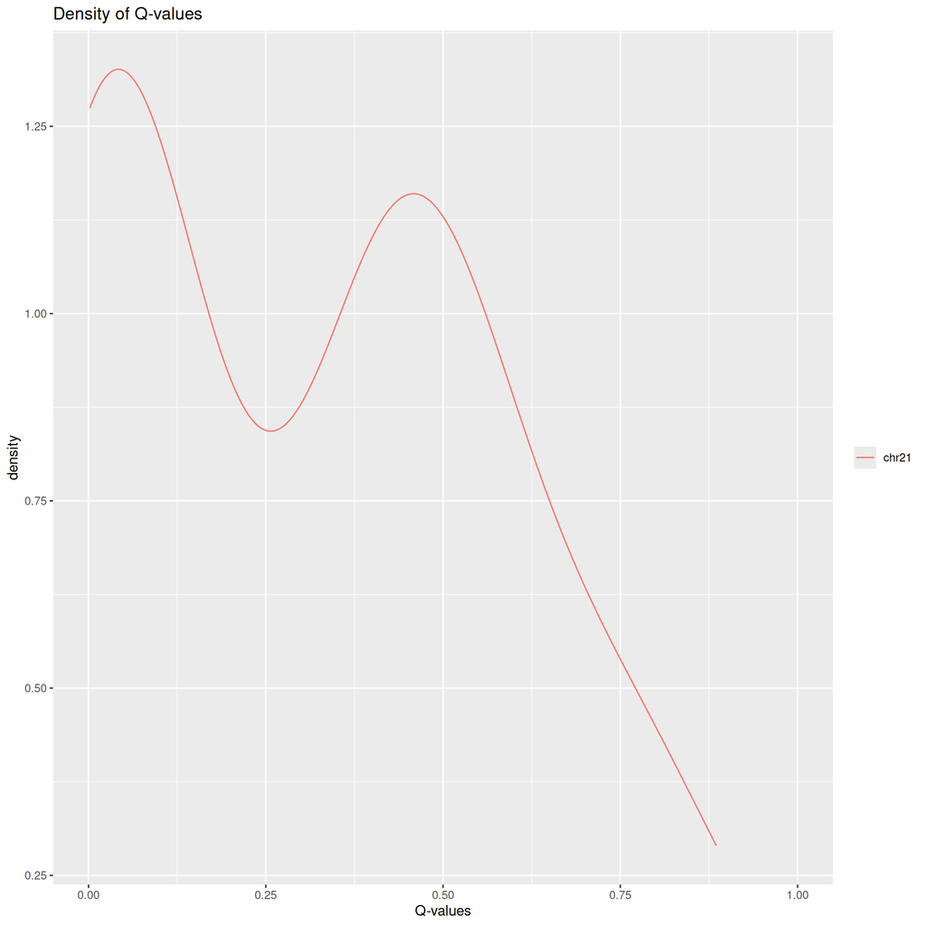

```r
p1qvalues <- ggplot(regions.df.plot, aes(x=qvalues, colour=seqnames)) +
    geom_line(stat='density') + xlim(0, 1) +
    labs(title='Density of Q-values') + xlab('Q-values') +
    scale_colour_discrete(limits=chrs) + theme(legend.title=element_blank())
p1qvalues
```

```r
summary(mcols(regions)[['qvalues']])
```

```
##     Min.  1st Qu.   Median     Mean  3rd Qu.     Max.
## 0.001848 0.012939 0.393715 0.314625 0.482440 0.885397
```

This is the numerical summary of the distribution of the Q-values.

```r
qvaluestable <- lapply(c(1e-04, 0.001, 0.01, 0.025, 0.05, 0.1, 0.2, 0.3, 0.4, 0.5,
    0.6, 0.7, 0.8, 0.9, 1), function(x) {
    data.frame('Cut' = x, 'Count' = sum(mcols(regions)[['qvalues']] <= x))
})
qvaluestable <- do.call(rbind, qvaluestable)
if(outputIsHTML) {
    kable(qvaluestable, format = 'markdown', align = c('c', 'c'))
} else {
    kable(qvaluestable)
}
```

| Cut | Count |
| --- | --- |
| 0.0001 | 0 |
| 0.0010 | 0 |
| 0.0100 | 7 |
| 0.0250 | 10 |
| 0.0500 | 10 |
| 0.1000 | 12 |
| 0.2000 | 15 |
| 0.3000 | 15 |
| 0.4000 | 19 |
| 0.5000 | 25 |
| 0.6000 | 28 |
| 0.7000 | 29 |
| 0.8000 | 32 |
| 0.9000 | 33 |
| 1.0000 | 33 |

This table shows the number of regions with Q-values less or equal than some commonly used cutoff values.

## 3.2 P-values

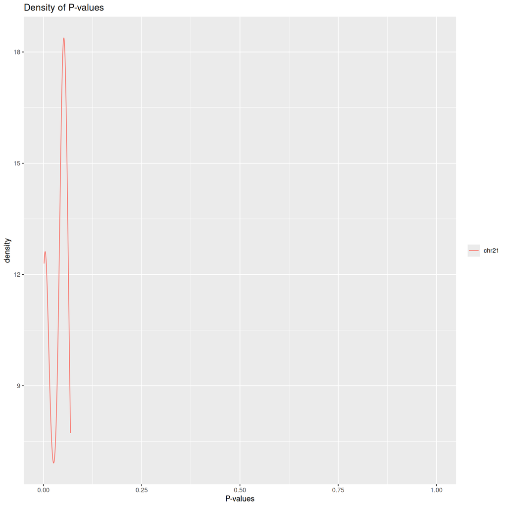

```r
p1pvalues <- ggplot(regions.df.plot, aes(x=pvalues, colour=seqnames)) +
    geom_line(stat='density') + xlim(0, 1) +
    labs(title='Density of P-values') + xlab('P-values') +
    scale_colour_discrete(limits=chrs) + theme(legend.title=element_blank())
p1pvalues
```

```r
summary(mcols(regions)[['pvalues']])
```

```
##     Min.  1st Qu.   Median     Mean  3rd Qu.     Max.
## 0.001581 0.003690 0.049524 0.033598 0.049524 0.068856
```

This is the numerical summary of the distribution of the P-values.

```r
pvaluestable <- lapply(c(1e-04, 0.001, 0.01, 0.025, 0.05, 0.1, 0.2, 0.3, 0.4, 0.5,
    0.6, 0.7, 0.8, 0.9, 1), function(x) {
    data.frame('Cut' = x, 'Count' = sum(mcols(regions)[['pvalues']] <= x))
})
pvaluestable <- do.call(rbind, pvaluestable)
if(outputIsHTML) {
    kable(pvaluestable, format = 'markdown', align = c('c', 'c'))
} else {
    kable(pvaluestable)
}
```

| Cut | Count |
| --- | --- |
| 0.0001 | 0 |
| 0.0010 | 0 |
| 0.0100 | 10 |
| 0.0250 | 12 |
| 0.0500 | 25 |
| 0.1000 | 33 |
| 0.2000 | 33 |
| 0.3000 | 33 |
| 0.4000 | 33 |
| 0.5000 | 33 |
| 0.6000 | 33 |
| 0.7000 | 33 |
| 0.8000 | 33 |
| 0.9000 | 33 |
| 1.0000 | 33 |

This table shows the number of regions with P-values less or equal than some commonly used cutoff values.

## 3.3 Region width

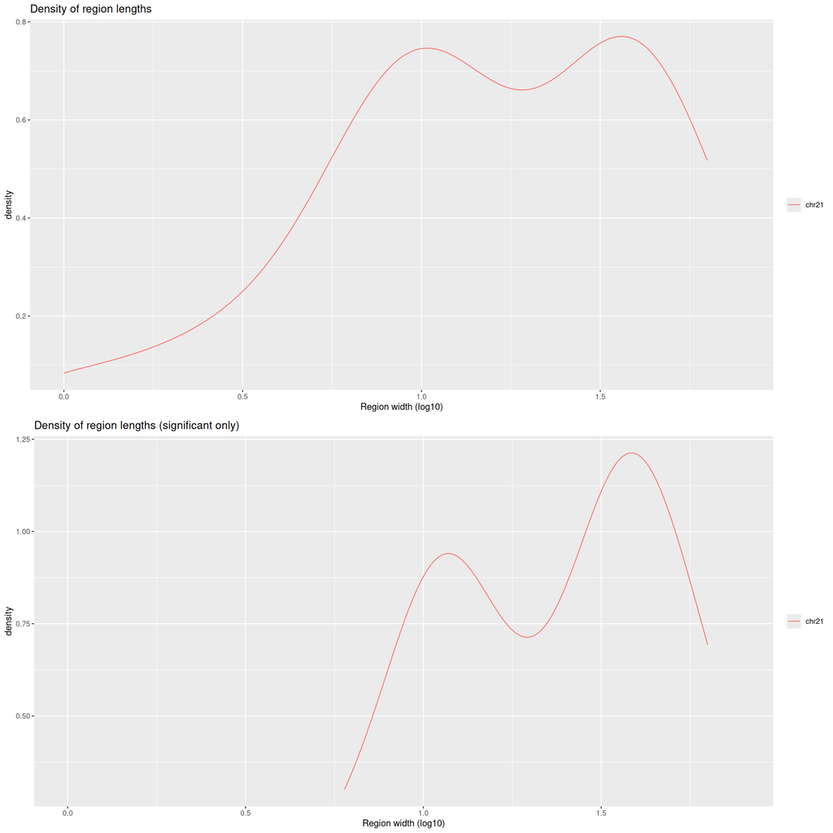

```r
xrange <- range(log10(regions.df.plot$width)) * c(0.95, 1.05)
p2a <- ggplot(regions.df.plot, aes(x=log10(width), colour=seqnames)) +
    geom_line(stat='density') + labs(title='Density of region lengths') +
    xlab('Region width (log10)') + scale_colour_discrete(limits=chrs) +
    xlim(xrange) + theme(legend.title=element_blank())
p2b <- ggplot(regions.df.sig, aes(x=log10(width), colour=seqnames)) +
    geom_line(stat='density') +
    labs(title='Density of region lengths (significant only)') +
    xlab('Region width (log10)') + scale_colour_discrete(limits=chrs) +
    xlim(xrange) + theme(legend.title=element_blank())
grid.arrange(p2a, p2b)
```

This plot shows the density of the region lengths for all regions. The bottom panel is restricted to significant regions.

```r
for(i in seq_len(length(densityVars))) {
    densityVarName <- names(densityVars[i])
    densityVarName <- ifelse(is.null(densityVarName), densityVars[i], densityVarName)
   cat(knit_child(text = whisker.render(templateDensityInUse, list(varName = densityVars[i], densityVarName = densityVarName)), quiet = TRUE), sep = '\n')
}
```

## 3.4 Area

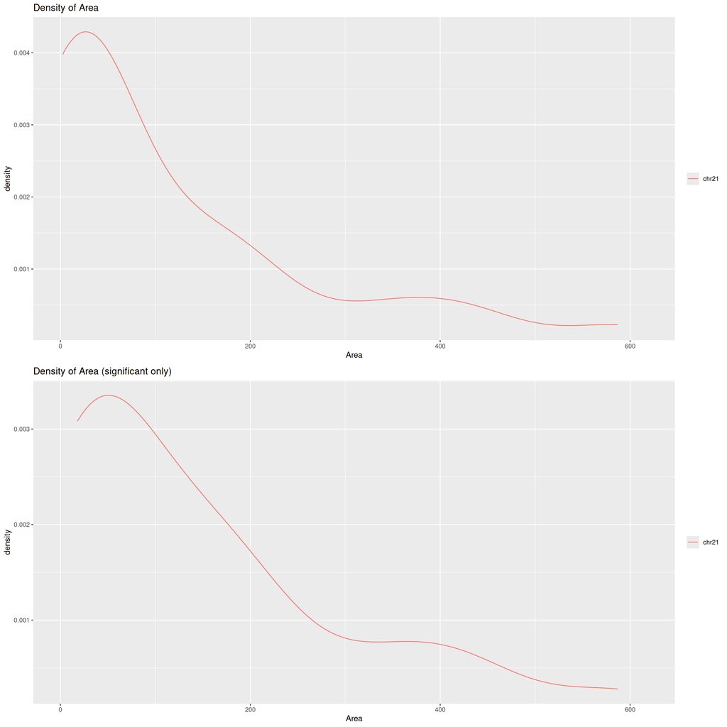

```r
xrange <- range(regions.df.plot[, 'area']) * c(0.95, 1.05)
p3aarea <- ggplot(regions.df.plot[is.finite(regions.df.plot[, 'area']), ], aes(x=area, colour=seqnames)) +
    geom_line(stat='density') + labs(title='Density of Area') +
    xlab('Area') + scale_colour_discrete(limits=chrs) +
    xlim(xrange) + theme(legend.title=element_blank())
p3barea <- ggplot(regions.df.sig[is.finite(regions.df.sig[, 'area']), ], aes(x=area, colour=seqnames)) +
    geom_line(stat='density') +
    labs(title='Density of Area (significant only)') +
    xlab('Area') + scale_colour_discrete(limits=chrs) +
    xlim(xrange) + theme(legend.title=element_blank())
grid.arrange(p3aarea, p3barea)
```

This plot shows the density of the Area for all regions. The bottom panel is restricted to significant regions.

## 3.5 Mean coverage

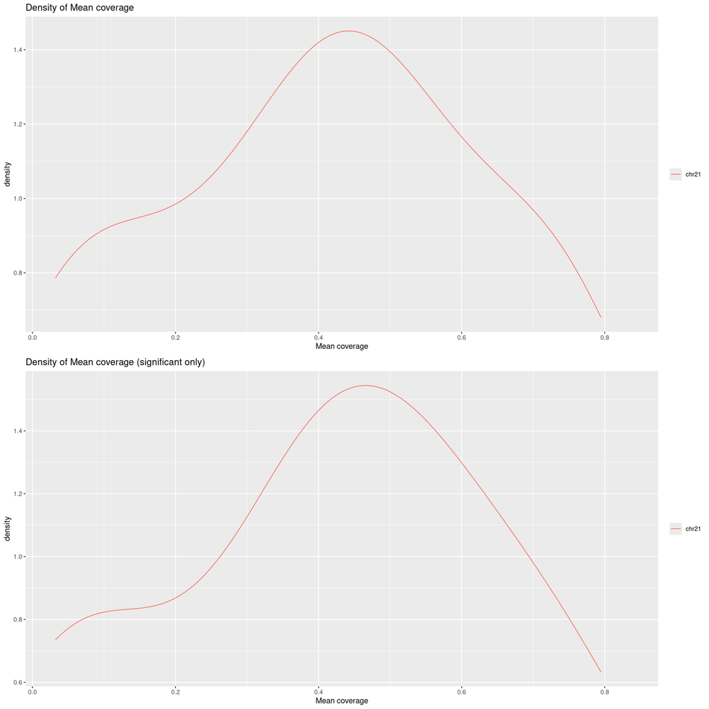

```r
xrange <- range(regions.df.plot[, 'meanCoverage']) * c(0.95, 1.05)
p3ameanCoverage <- ggplot(regions.df.plot[is.finite(regions.df.plot[, 'meanCoverage']), ], aes(x=meanCoverage, colour=seqnames)) +
    geom_line(stat='density') + labs(title='Density of Mean coverage') +
    xlab('Mean coverage') + scale_colour_discrete(limits=chrs) +
    xlim(xrange) + theme(legend.title=element_blank())
p3bmeanCoverage <- ggplot(regions.df.sig[is.finite(regions.df.sig[, 'meanCoverage']), ], aes(x=meanCoverage, colour=seqnames)) +
    geom_line(stat='density') +
    labs(title='Density of Mean coverage (significant only)') +
    xlab('Mean coverage') + scale_colour_discrete(limits=chrs) +
    xlim(xrange) + theme(legend.title=element_blank())
grid.arrange(p3ameanCoverage, p3bmeanCoverage)
```

This plot shows the density of the Mean coverage for all regions. The bottom panel is restricted to significant regions.

# 4 Genomic overview

The following plots were made using `ggbio` (Yin, Cook, and Lawrence, 2012) which in turn uses `ggplot2` (Wickham, 2016). For more details check `plotOverview` in `derfinderPlot` (Collado-Torres, Jaffe, and Leek, 2017).

## 4.1 P-values

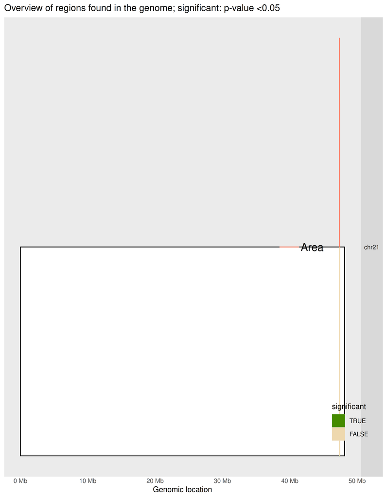

```r
## Choose what variable to show on the top
tmp <- regions
tmp$significant <- factor(significantVar, levels = c('TRUE', 'FALSE'))
if(!'area' %in% colnames(mcols(tmp))) {
    if(hasDensityVars) {
        tmp$area <- mcols(tmp)[[densityVars[1]]]
        areaVar <- densityVars[1]
        areaVar <- ifelse(is.null(names(areaVar)), densityVars[1], names(areaVar))
    } else {
        tmp$area <- 0
        areaVar <- NULL
    }
} else {
    areaVar <- 'area'
}
plotOverview(regions=tmp, type='pval', base_size=overviewParams$base_size, areaRel=overviewParams$areaRel, legend.position=c(0.97, 0.12))
```

```r
rm(tmp)
```

This plot shows the genomic locations of the regions found in the analysis. The significant regions are highlighted and the area of the regions is shown on top of each chromosome (shown in a relative scale).

```r
for(i in seq_len(length(pvalueVars))) {
    densityVarName <- names(pvalueVars[i])
    densityVarName <- ifelse(is.null(densityVarName), pvalueVars[i], densityVarName)
   cat(knit_child(text = whisker.render(templateManhattanInUse, list(varName = pvalueVars[i], densityVarName = densityVarName)), quiet = TRUE), sep = '\n')
}
```

## 4.2 Manhattan Q-values

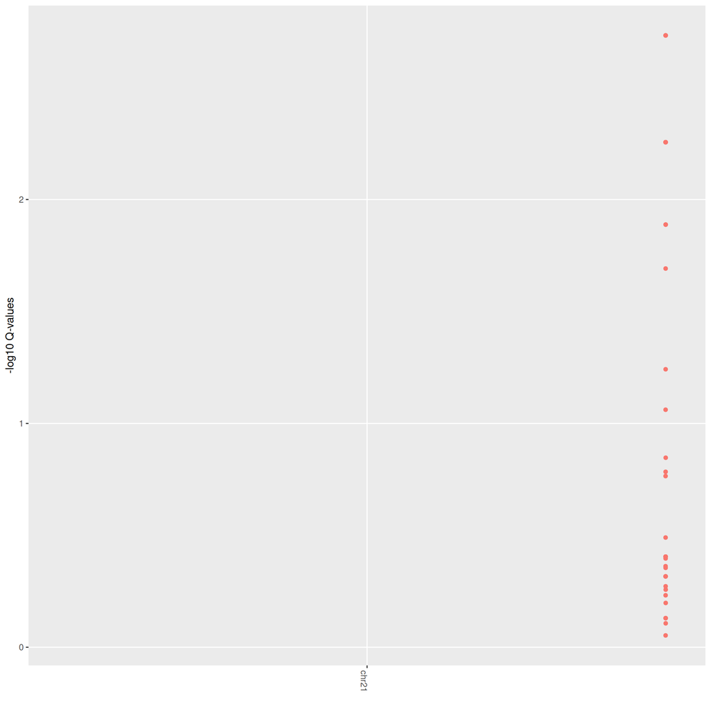

```r
regions.manhattan <- regions
mcols(regions.manhattan)[['qvalues']] <- - log(mcols(regions.manhattan)[['qvalues']], base = 10)
pManqvalues <- plotGrandLinear(regions.manhattan, aes(y = qvalues, colour = seqnames)) + theme(axis.text.x=element_text(angle=-90, hjust=0)) + ylab('-log10 Q-values')
pManqvalues
```

```r
rm(regions.manhattan)
```

This is a Manhattan plot for the Q-values for all regions. A single dot is shown for each region, where higher values in the y-axis mean that the Q-values are closer to zero.

## 4.3 Manhattan P-values

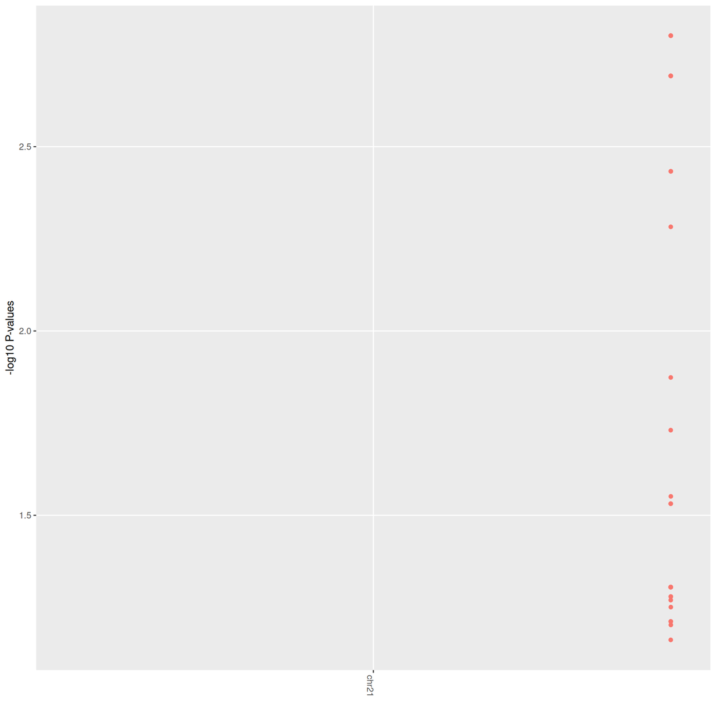

```r
regions.manhattan <- regions
mcols(regions.manhattan)[['pvalues']] <- - log(mcols(regions.manhattan)[['pvalues']], base = 10)
pManpvalues <- plotGrandLinear(regions.manhattan, aes(y = pvalues, colour = seqnames)) + theme(axis.text.x=element_text(angle=-90, hjust=0)) + ylab('-log10 P-values')
pManpvalues
```

```r
rm(regions.manhattan)
```

This is a Manhattan plot for the P-values for all regions. A single dot is shown for each region, where higher values in the y-axis mean that the P-values are closer to zero.

## 4.4 Annotation

```r
## Annotate regions with bumphunter
if(is.null(annotation)) {
    genes <- annotateTranscripts(txdb = txdb)
    annotation <- matchGenes(x = regions, subject = genes)
}
```

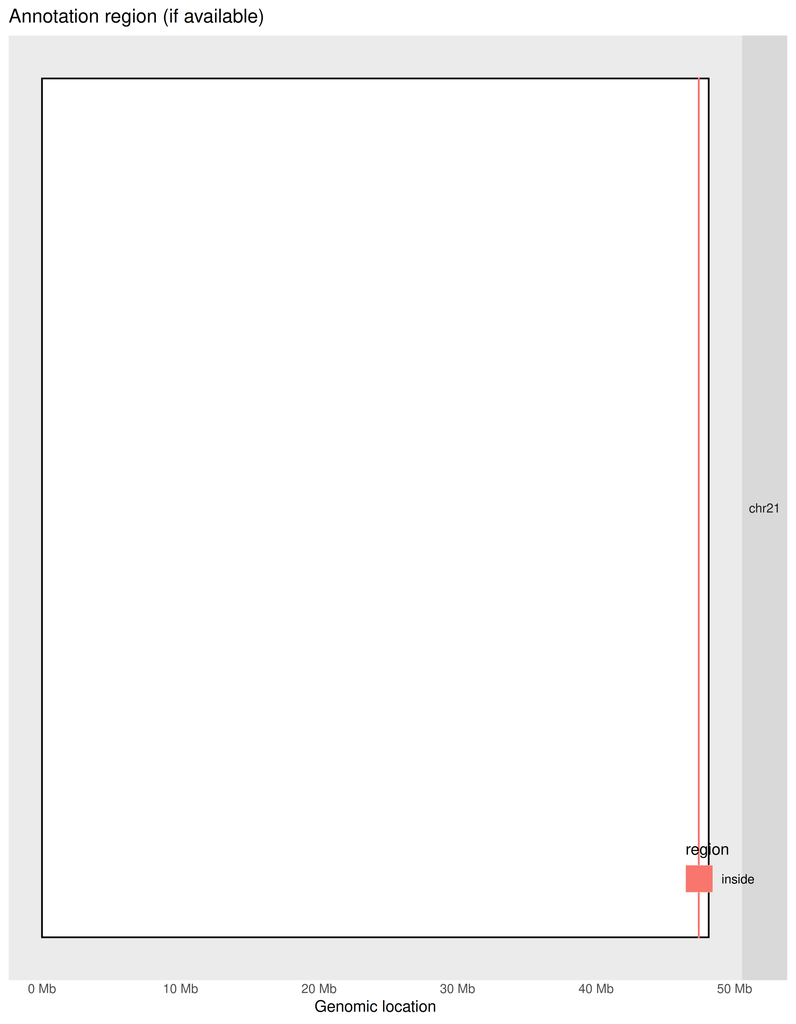

```r
## Make the plot
plotOverview(regions=regions, annotation=annotation, type='annotation', base_size=overviewParams$base_size, areaRel=overviewParams$areaRel, legend.position=c(0.97, 0.12))
```

This genomic overview plot shows the annotation region type for the regions as determined using `bumphunter` (Jaffe, Murakami, Lee, Leek, Fallin, Feinberg, and Irizarry, 2012). Note that the regions are shown only if the annotation information is available. Below is a table of the actual number of results per annotation region type.

```r
annoReg <- table(annotation$region, useNA='always')
annoReg.df <- data.frame(Region=names(annoReg), Count=as.vector(annoReg))
if(outputIsHTML) {
    kable(annoReg.df, format = 'markdown', align=rep('c', 3))
} else {
    kable(annoReg.df)
}
```

| Region | Count |
| --- | --- |
| upstream | 0 |
| promoter | 0 |
| overlaps 5’ | 0 |
| inside | 33 |
| overlaps 3’ | 0 |
| close to 3’ | 0 |
| downstream | 0 |
| covers | 0 |
| NA | 0 |

## 4.5 Annotation (significant)

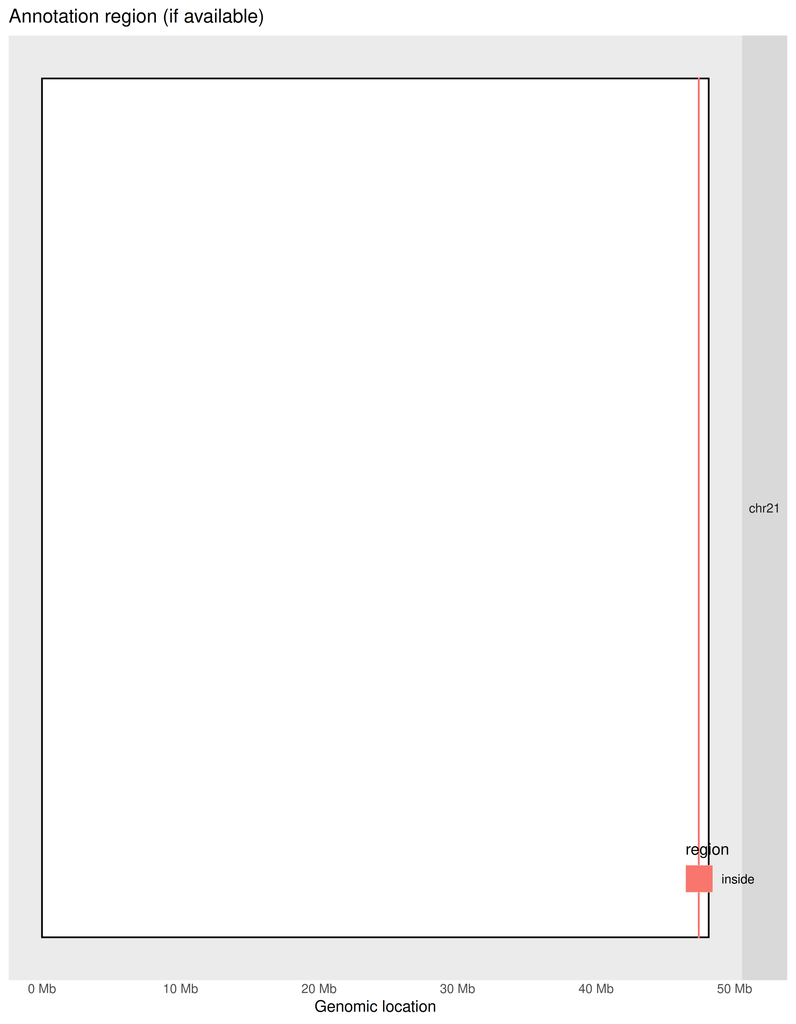

```r
plotOverview(regions=regions[significantVar, ], annotation=annotation[significantVar, ], type='annotation', base_size=overviewParams$base_size, areaRel=overviewParams$areaRel, legend.position=c(0.97, 0.12))
```

This genomic overview plot shows the annotation region type for the statistically significant regions. Note that the regions are shown only if the annotation information is available.

# 5 Best regions

## 5.1 Genomic states

Below is a table summarizing the number of genomic states per region as determined using `derfinder` (Collado-Torres, Nellore, Frazee et al., 2017).

```r
## Construct genomic state object
genomicState <- makeGenomicState(txdb = txdb, chrs = chrs, verbose = FALSE)
## Annotate regions by genomic state
annotatedRegions <- annotateRegions(regions, genomicState$fullGenome, verbose = FALSE)

## Genomic states table
info <- do.call(rbind, lapply(annotatedRegions$countTable, function(x) { data.frame(table(x)) }))
colnames(info) <- c('Number of Overlapping States', 'Frequency')
info$State <- gsub('\\..*', '', rownames(info))
rownames(info) <- NULL
if(outputIsHTML) {
    kable(info, format = 'markdown', align=rep('c', 4))
} else {
    kable(info)
}
```

| Number of Overlapping States | Frequency | State |
| --- | --- | --- |
| 0 | 3 | exon |
| 1 | 30 | exon |
| 0 | 33 | intergenic |
| 0 | 29 | intron |
| 1 | 4 | intron |

The following is a venn diagram showing how many regions overlap known exons, introns, and intergenic segments, none of them, or multiple of these groups.

```r
## Venn diagram for all regions
venn <- vennRegions(annotatedRegions, counts.col = 'blue',
    main = 'Regions overlapping genomic states')
```

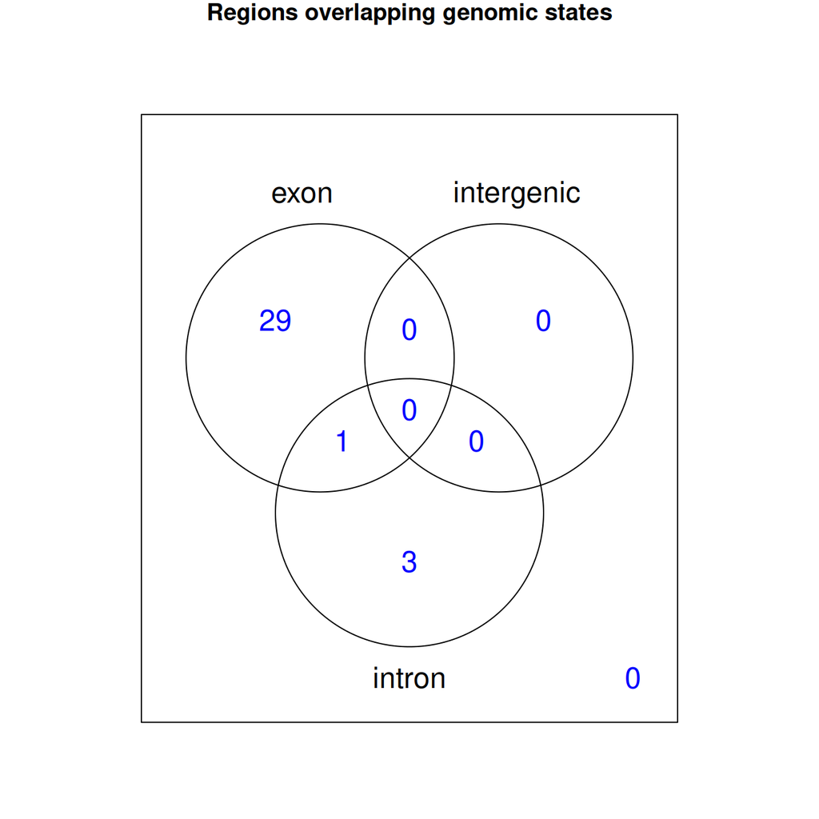

The following plot is the genomic states venn diagram only for the significant regions.

```r
## Venn diagram for all regions
vennSig <- vennRegions(annotatedRegions, counts.col = 'blue',
    main = 'Significant regions overlapping genomic states',
    subsetIndex = significantVar)
```

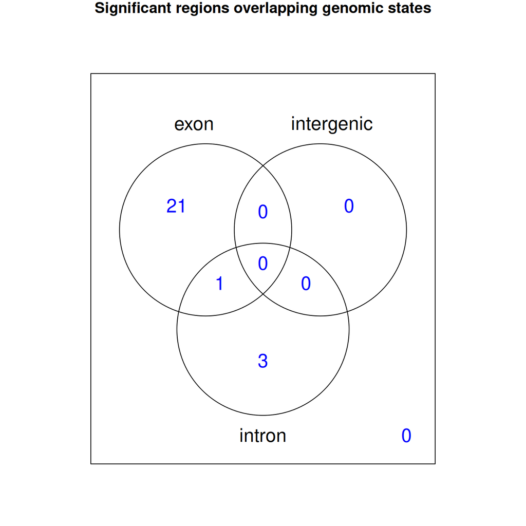

## 5.2 Region information

Below is an interactive table with the top 20 regions (out of 33) as ranked by p-value . Inf and -Inf are shown as 1e100 and -1e100 respectively. Use the search function to find your region of interest or sort by one of the columns.

```r
## Add annotation information
regions.df <- cbind(regions.df, annotation)

## Rank by p-value (first pvalue variable supplied)
if(hasPvalueVars){
    topRegions <- head(regions.df[order(regions.df[, pvalueVars[1]],
        decreasing = FALSE), ], nBestRegions)
    topRegions <- cbind(data.frame('pvalueRank' = seq_len(nrow(topRegions))),
        topRegions)
} else {
    topRegions <- head(regions.df, nBestRegions)
}

## Clean up -Inf, Inf if present
## More details at https://github.com/ramnathv/rCharts/issues/259
replaceInf <- function(df, colsubset=seq_len(ncol(df))) {
    for(i in colsubset) {
        inf.idx <- !is.finite(df[, i])
        if(any(inf.idx)) {
            inf.sign <- sign(df[inf.idx, i])
            df[inf.idx, i] <- inf.sign * 1e100
        }
    }
    return(df)
}
topRegions <- replaceInf(topRegions, which(sapply(topRegions, function(x) {
    class(x) %in% c('numeric', 'integer')})))

## Make the table
greptext <- 'value$|area$|mean|log2FoldChange'
greppval <- 'pvalues$|qvalues$|fwer$'
if(hasPvalueVars) {
    greppval <- paste0(paste(pvalueVars, collapse = '$|'), '$|', greppval)
}
if(hasDensityVars) {
    greptext <- paste0(paste(densityVars, collapse = '$|'), '$|', greptext)
}

for(i in which(grepl(greppval, colnames(topRegions)))) topRegions[, i] <- format(topRegions[, i], scientific = TRUE)

if(outputIsHTML) {
    datatable(topRegions, options = list(pagingType='full_numbers', pageLength=10, scrollX='100%'), rownames = FALSE) %>% formatRound(which(grepl(greptext, colnames(topRegions))), digits)
} else {
    ## Only print the top part if your output is a PDF file
    df_top <- head(topRegions, 20)
    for(i in which(grepl(greptext, colnames(topRegions)))) df_top[, i] <- round(df_top[, i], digits)
    kable(df_top)
}
```

| pvalueRank | seqnames | start | end | width | strand | value | area | indexStart | indexEnd | cluster | clusterL | meanCoverage | meanCEU | meanYRI | log2FoldChangeYRIvsCEU | qvalues | significant | pvalues | significantQval | name | annotation | description | region | distance | subregion | insideDistance | exonnumber | nexons | UTR | … |
| --- | --- | --- | --- | --- | --- | --- | --- | --- | --- | --- | --- | --- | --- | --- | --- | --- | --- | --- | --- | --- | --- | --- | --- | --- | --- | --- | --- | --- | --- | --- |
| 1 | chr21 | 47409522 | 47409560 | 39 | * | 15.05364387160544 | 587.092110992612 | 128 | 166 | 3 | 167 | 0.4152191894127378 | 0.6129426129426131 | 0 | -1e+100 | 1.848429e-03 | TRUE | 1.581241e-03 | TRUE |  |  | inside exon | inside | 7838 | inside exon | 0 | 10 | 35 | inside transcription region | … |
| 2 | chr21 | 47411924 | 47411986 | 63 | * | 7.096703515079597 | 447.0923214500146 | 618 | 680 | 6 | 389 | 0.5847414234511007 | 0.8374905517762662 | 0.05396825396825397 | -3.955889996907451 | 1.848429e-03 | TRUE | 1.581241e-03 | TRUE |  |  | inside exon | inside | 10240 | inside exon | 0 | 16 | 35 | inside transcription region | … |
| 3 | chr21 | 47417352 | 47417397 | 46 | * | 8.778445451939167 | 403.8084907892016 | 1292 | 1337 | 10 | 338 | 0.364656381486676 | 0.5331262939958593 | 0.0108695652173913 | -5.61611119929182 | 1.848429e-03 | TRUE | 1.581241e-03 | TRUE |  |  | inside exon | inside | 3381 | inside exon | 0 | 2 | 5 | inside transcription region | … |
| 4 | chr21 | 47412662 | 47412724 | 63 | * | 5.671215887767281 | 357.2866009293387 | 843 | 905 | 7 | 63 | 0.5012800819252431 | 0.7399848828420256 | 0 | -1e+100 | 5.545287e-03 | TRUE | 2.033024e-03 | TRUE |  |  | inside exon | inside | 10978 | inside exon | 0 | 19 | 35 | inside transcription region | … |
| 5 | chr21 | 47408998 | 47409026 | 29 | * | 10.68525160402291 | 309.8722965166644 | 69 | 97 | 2 | 232 | 0.1957730812013348 | 0.2889983579638752 | 0 | -1e+100 | 5.545287e-03 | TRUE | 2.033024e-03 | TRUE |  |  | inside exon | inside | 7314 | inside exon | 0 | 9 | 35 | inside transcription region | … |
| 6 | chr21 | 47414081 | 47414143 | 63 | * | 3.308408226636284 | 208.4297182780859 | 994 | 1056 | 8 | 63 | 0.3645673323092677 | 0.5381708238851096 | 0 | -1e+100 | 5.545287e-03 | TRUE | 2.033024e-03 | TRUE |  |  | inside exon | inside | 110 | inside exon | 0 | 1 | 5 | inside transcription region | … |
| 7 | chr21 | 47410893 | 47410930 | 38 | * | 5.45257294008623 | 207.1977717232768 | 407 | 444 | 5 | 269 | 0.4151103565365025 | 0.6127819548872181 | 0 | -1e+100 | 5.545287e-03 | TRUE | 2.033024e-03 | TRUE |  |  | inside exon | inside | 9209 | inside exon | 0 | 15 | 35 | inside transcription region | … |
| 8 | chr21 | 47416094 | 47416131 | 38 | * | 5.109484425366996 | 194.1604081639458 | 1165 | 1202 | 9 | 222 | 0.03225806451612903 | 0.04761904761904762 | 0 | -1e+100 | 1.293900e-02 | TRUE | 3.689562e-03 | TRUE |  |  | inside intron | inside | 2123 | inside intron | 1203 | 2 | 5 | inside transcription region | … |
| 9 | chr21 | 47415910 | 47415945 | 36 | * | 5.109484425366996 | 183.9414393132118 | 1129 | 1164 | 9 | 222 | 0.03225806451612903 | 0.04761904761904762 | 0 | -1e+100 | 1.293900e-02 | TRUE | 3.689562e-03 | TRUE |  |  | inside intron | inside | 1939 | inside intron | 1389 | 2 | 5 | inside transcription region | … |
| 10 | chr21 | 47412088 | 47412131 | 44 | * | 3.344260693814288 | 147.1474705278287 | 691 | 734 | 6 | 389 | 0.4464809384164222 | 0.6590909090909093 | 0 | -1e+100 | 2.033272e-02 | TRUE | 5.218095e-03 | TRUE |  |  | inside exon | inside | 10404 | inside exon | 0 | 17 | 35 | inside transcription region | … |

[output cut: 10 more lines]

# 6 Reproducibility

This report was generated in path /__w/regionReport/regionReport/docs/reference using the following call to `renderReport()`:

```
## renderReport(regions = regions, project = "Example run", pvalueVars = c(`Q-values` = "qvalues",
##     `P-values` = "pvalues"), densityVars = c(Area = "area", `Mean coverage` = "meanCoverage"),
##     significantVar = regions$qvalues <= 0.05, nBestRegions = 20,
##     outdir = "renderReport-example")
```

Date the report was generated.

```
## [1] "2026-03-31 17:57:52 UTC"
```

Wallclock time spent generating the report.

```
## Time difference of 1.172 mins
```

Pandoc version used: 3.9.0.2.

# 7 Bibliography

This report was created with `regionReport` (Collado-Torres, Jaffe, and Leek, 2016) using `rmarkdown` (Allaire, Xie, Dervieux et al., 2026) while `knitr` (Xie, 2014) and `DT` (Xie, Cheng, Tan et al., 2025) were running behind the scenes. `whisker` (de Jonge, 2022) was used for creating templates for the `pvalueVars` and `densityVars`.

Citations made with *RefManageR* (McLean, 2017). The [BibTeX](http://www.bibtex.org/) file can be found here.

[1] J. Allaire, Y. Xie, C. Dervieux, et al. *rmarkdown: Dynamic Documents for R*. R package version 2.31. 2026. URL: https://github.com/rstudio/rmarkdown.

[2] L. Collado-Torres, A. E. Jaffe, and J. T. Leek. *derfinderPlot: Plotting functions for derfinder*. https://github.com/leekgroup/derfinderPlot - R package version 1.45.0. 2017. DOI: 10.18129/B9.bioc.derfinderPlot. URL: http://www.bioconductor.org/packages/derfinderPlot.

[3] L. Collado-Torres, A. E. Jaffe, and J. T. Leek. “regionReport: Interactive reports for region-level and feature-level genomic analyses [version2; referees: 2 approved, 1 approved with reservations]”. In: *F1000Research* 4 (2016), p. 105. DOI: 10.12688/f1000research.6379.2. URL: http://f1000research.com/articles/4-105/v2.

[4] L. Collado-Torres, A. Nellore, A. C. Frazee, et al. “Flexible expressed region analysis for RNA-seq with derfinder”. In: *Nucl. Acids Res.* (2017). DOI: 10.1093/nar/gkw852. URL: http://nar.oxfordjournals.org/content/early/2016/09/29/nar.gkw852.

[5] A. E. Jaffe, P. Murakami, H. Lee, et al. “Bump hunting to identify differentially methylated regions in epigenetic epidemiology studies”. In: *International journal of epidemiology* 41.1 (2012), pp. 200–209. DOI: 10.1093/ije/dyr238.

[6] M. W. McLean. “RefManageR: Import and Manage BibTeX and BibLaTeX References in R”. In: *The Journal of Open Source Software* (2017). DOI: 10.21105/joss.00338.

[7] H. Wickham. *ggplot2: Elegant Graphics for Data Analysis*. Springer-Verlag New York, 2016. ISBN: 978-3-319-24277-4. URL: https://ggplot2.tidyverse.org.

[8] Y. Xie. “knitr: A Comprehensive Tool for Reproducible Research in R”. In: *Implementing Reproducible Computational Research*. Ed. by V. Stodden, F. Leisch and R. D. Peng. ISBN 978-1466561595. Chapman and Hall/CRC, 2014.

[9] Y. Xie, J. Cheng, X. Tan, et al. *DT: A Wrapper of the JavaScript Library ‘DataTables’*. R package version 0.34.0. 2025. DOI: 10.32614/CRAN.package.DT. URL: https://CRAN.R-project.org/package=DT.

[10] T. Yin, D. Cook, and M. Lawrence. “ggbio: an R package for extending the grammar of graphics for genomic data”. In: *Genome Biology* 13.8 (2012), p. R77.

[11] E. de Jonge. *whisker: mustache for R, Logicless Templating*. R package version 0.4.1. 2022. DOI: 10.32614/CRAN.package.whisker. URL: https://CRAN.R-project.org/package=whisker.